# Irreducibla Markovkedjor

gean piere ventura cruz

2022-02-17

Uppgift 1

1. Visuell tolkning av sannolikhetsfördelning för dess tillstånd under flera dagars perioder då automaten utan några fel. Sannolikheterna är avrundade till 4 decimaler.

```r
df <- data.frame(Tid = c("På onsdag", "Om en vecka",
"Om två veckor", "Om tre månader"))
df <- cbind(df, rbind(c(0.000, 0.000, 0.048, 0.272, 0.432, 0.248), c(0.0024960, 0.0272736, 0.1242672, 0.3153496, 0.2614016, 0.2711120), c(0.002581384, 0.02582675, 0.1163860, 0.3107785, 0.2724897, 0.2719376), c(0.002590674, 0.02590674, 0.1165803, 0.3108808, 0.2720207, 0.2720207)))
names(df)[-1] <- paste0("Tillstånd ", 0:5)
knitr::kable(df, digits = 4, caption = "Tabell 1.1 tillståndsverktorer efter olika antal dagar med start från tillstånd 5")
```

Tabell 1.1 tillståndsverktorer efter olika antal dagar med start från tillstånd 5

| Tid | Tillstånd 0 | Tillstånd 1 | Tillstånd 2 | Tillstånd 3 | Tillstånd 4 | Tillstånd 5 |
| --- | --- | --- | --- | --- | --- | --- |
| På onsdag | 0.0000 | 0.0000 | 0.0480 | 0.2720 | 0.4320 | 0.2480 |
| Om en vecka | 0.0025 | 0.0273 | 0.1243 | 0.3153 | 0.2614 | 0.2711 |
| Om två veckor | 0.0026 | 0.0258 | 0.1164 | 0.3108 | 0.2725 | 0.2719 |
| Om tre månader | 0.0026 | 0.0259 | 0.1166 | 0.3109 | 0.2720 | 0.2720 |

2. Den här gången befinner sig automaten i tillstånd 3.

```r
df <- data.frame(Tid = c("På torsdag", "Om en vecka",
"Om två veckor", "Om tre månader"))
df <- cbind(df, rbind(c(0.0048, 0.0336, 0.1155, 0.2787, 0.2396, 0.3278), c(0.0023988, 0.0238080, 0.1105299, 0.3060033, 0.2849188, 0.2723412), c(0.002600479, 0.02596195, 0.1166557, 0.3108168, 0.2717323, 0.2722328), c(0.002590674, 0.02590674, 0.1165803, 0.3108808, 0.2720207, 0.2720207)))
names(df)[-1] <- paste0("Tillstånd ", 0:5)
knitr::kable(df, digits = 4, caption = "Tabell 1.2 tillståndsverktorer efter olika antal dagar med start från tillstånd 3")
```

Tabell 1.2 tillståndsverktorer efter olika antal dagar med start från tillstånd 3

| Tid | Tillstånd 0 | Tillstånd 1 | Tillstånd 2 | Tillstånd 3 | Tillstånd 4 | Tillstånd 5 |
| --- | --- | --- | --- | --- | --- | --- |
| På torsdag | 0.0048 | 0.0336 | 0.1155 | 0.2787 | 0.2396 | 0.3278 |
| Om en vecka | 0.0024 | 0.0238 | 0.1105 | 0.3060 | 0.2849 | 0.2723 |
| Om två veckor | 0.0026 | 0.0260 | 0.1167 | 0.3108 | 0.2717 | 0.2722 |
| Om tre månader | 0.0026 | 0.0259 | 0.1166 | 0.3109 | 0.2720 | 0.2720 |

Tabellerna, 1.1 och 1.2 verkar konvergera mot ett gränsvärde för de olika tillstånd (0-5). Vi sedan märker att ju fler dagar vi itererar över kommer tabellernas rader att konvergera mot samma värde och oberoende av valt starttillstånd.

Uppgift 2

```r
mpow <- function(P, n) {
  resultat <- diag(nrow(P))
  potens <- n
  while (potens > 0) {
    resultat <- P %*% resultat
    potens <- potens - 1
  }
  return(resultat)
}
P =  matrix(c(0, 0, 0, 0.5, 0, 0.5,
              0.1, 0.1, 0, 0.4, 0, 0.4,
              0, 0.2, 0.2, 0.3, 0, 0.3,
              0, 0, 0.3, 0.5, 0, 0.2,
              0, 0, 0, 0.4, 0.6, 0,
              0, 0, 0, 0, 0.4, 0.6),
            byrow = TRUE,
            nrow = 6,
            ncol = 6)
Q = matrix(c(0, 0, 0, 0.5, 0, 0.5,
              0.1, 0.1, 0, 0.4, 0, 0.4,
              0, 0.2, 0.2, 0.3, 0, 0.3,
              0, 0, 0.3, 0.5, 0, 0.2,
              0, 0, 0, 0.4, 0.6, 0,
              0, 0, 0, 0, 0.4, 0.6),
            byrow = TRUE,
            nrow = 6,
            ncol = 6)
```

```r
rows_equal <- function(P, d = 4) {
  P_new <- trunc(P * 10^d) # förstora talet och ta heltalsdelen
  for (k in 2:nrow(P_new)) {
    if (!all(P_new[1, ] == P_new[k, ])) {
      return(FALSE)
    }
  }
  return(TRUE)
}
c=mpow(P,20)
rows_equal(c,d = 4)
```

```
## [1] TRUE
```

```r
matrices_equal <- function(P, Q, d = 4) {
  P_new <- trunc(P * 10^d)
  Q_new <- trunc(Q * 10^d)
  if (all(P_new == Q_new)) {
    return(TRUE)
  } else {
    return(FALSE)
  }
}
p=mpow(P,20)
q=mpow(Q,21)
matrices_equal(P,q,d=4)
```

```
## [1] FALSE
```

Ett exempel på en sådan rad som konvergerar ser ut på följande sätt:

```r
df <- data.frame(n = c("20"))
df <- cbind(df, rbind(c(0.002590259, 0.02590481, 0.1165789,0.3108859, 0.2720300, 0.2720100)))
names(df)[-1] <- paste0("Tillstånd ", 0:5)
knitr::kable(df, digits = 4, caption = "Tabell 2 tillståndsvektor efter 20 dagar")
```

Tabell 2 tillståndsvektor efter 20 dagar

| n | Tillstånd 0 | Tillstånd 1 | Tillstånd 2 | Tillstånd 3 | Tillstånd 4 | Tillstånd 5 |
| --- | --- | --- | --- | --- | --- | --- |
| 20 | 0.0026 | 0.0259 | 0.1166 | 0.3109 | 0.272 | 0.272 |

b)Vi börjar med ange vår givna matris P som den sedan multipliceras med en vektor $\pi_i$ för varje tillstånd. Som sedan adderas för att sedan få långtidsproportionen av övergångar från tillstånd i till j. Samt ska summan av alla långtidsproportionerna vara lika med 1. Vi kan då ställa upp följande funktion som löser denna typ av ekvation:
$$(P^t-I)\pi=0$$

```r
P =  matrix(c(0, 0, 0, 0.5, 0, 0.5,
              0.1, 0.1, 0, 0.4, 0, 0.4,
              0, 0.2, 0.2, 0.3, 0, 0.3,
              0, 0, 0.3, 0.5, 0, 0.2,
              0, 0, 0, 0.4, 0.6, 0,
              0, 0, 0, 0, 0.4, 0.6),
            byrow = TRUE,
            nrow = 6,
            ncol = 6)
A= t(P)-diag(6)
A[5,] = rep(1,6)
y = c(0,0,0,0,1,0)
pi=solve(A, y)
pi
```

```
## [1] 0.002590674 0.025906736 0.116580311 0.310880829 0.272020725 0.272020725
```

Lösningen av matrisekvationen ovan ger övergångsmatrisens P:s stationära fördelning.

Uppgift 3

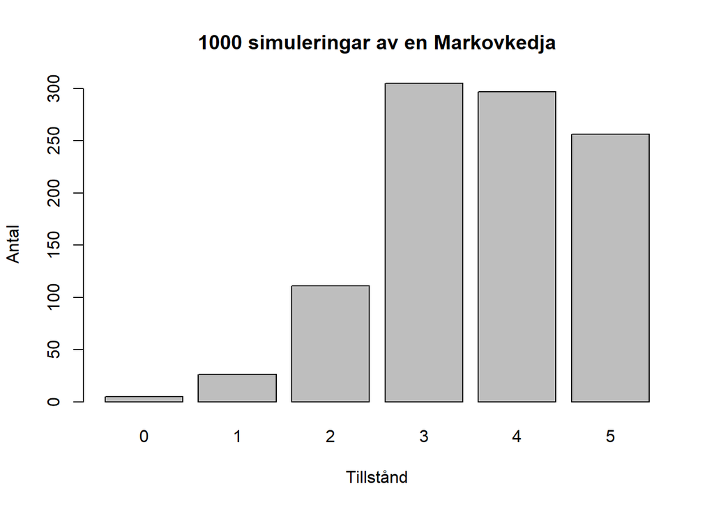

```r
gen_sim <- function(x, P) {
  u <- runif(1)
  y <- 0
  test <- P[x + 1, 1]
  while (u > test) {
    y <- y + 1
    test <- test + P[x + 1, y + 1]
  }
  y
}

P =  matrix(c(0, 0, 0, 0.5, 0, 0.5,
              0.1, 0.1, 0, 0.4, 0, 0.4,
              0, 0.2, 0.2, 0.3, 0, 0.3,
              0, 0, 0.3, 0.5, 0, 0.2,
              0, 0, 0, 0.4, 0.6, 0,
              0, 0, 0, 0, 0.4, 0.6),
            byrow = TRUE,
            nrow = 6,
            ncol = 6)
set.seed(1)

simulera_kedja <- function(x, n, P) {
  results <- numeric(n + 1) # vektor av nollor, till en början
  results[1] <- x # första elementet är initialtillståndet
  for (i in 2:n) {
    results[i] <- gen_sim(results[i - 1], P) # simulera övriga element
  }
  # ta bort initialtillståndet och returnera vektorn med simulerade tillstånd
  results[-1]
}
results2 <- simulera_kedja(5, 1000, P)

barplot(table(results2),
        xlab = "Tillstånd",
        ylab = "Antal",
        main = "1000 simuleringar av en Markovkedja")
```

Diagram 1 visar en simulering av hur övergångsmatrisen fördelar dig i de olika tillstånd upp till dag 1000.

Vi märker genast att detta stämmer med den statiönära fördelningen i tabell 2. Det går att se att i tabell 2 så är tillstånd 3 vanligast då den har högst sannolikhet att hända. Tillstånd 4 kommer på en andra plats och så vidare för resterande tillstånd. Detta resultat har då illustrerats i diagram 1.

Uppgift 4 a)

```r
#functionen räknar ut hur många gånger vi är i tillstånd 5 och hur många gånger vi
#är i tillstånd 1 innan vi kommer till tillstånd 5.
tillstånd_5=0
tillstånd_1_5=0
for (i in 2:1000){
  if(results2[i] == 5){ #gånger vi är i tillstånd 5
    tillstånd_5 = tillstånd_5 + 1
  }
  if(results2[i]==5 && results2[i-1] == 1){ #gånger vi är i tillstånd 1 innan vi kommer till tillstånd 5
    tillstånd_1_5 = tillstånd_1_5 + 1
  }
}
tillstånd_1_5/tillstånd_5
```

```
## [1] 0.03515625
```

2. Vi tillämpar Bayes formel, vilket ger oss följande formel:
   $$P[(X_{n-1}=1)|(X_n)=5]=\frac{P[(X_{n-1})\cap P(X_n=5)]}{P(X_n=5)}=\frac{P_{15}\cdot P(X_{n-1}=1)}{P(X_n=5)}$$
   Sannolikhet att tillstånd 1 kommunicerar med 5 är 0.4, P(Xn=5)=0.2720 och P(Xn-1=1)=0.0259. Detta oss en sannolikhet på 0.038.